# GGPLOT2 Tutorial

Carlos Yordan

6/3/2022

For this tutorial, We will be using three data sources:

- The metadata for my team’s UN General Debate (UNGD) project.
- The `gapminder` database which includes a ton of economic and demographic variables
- Data on the ratification of the UN’s core human rights instruments, collected by Jeehae and Julia

## The Number of Democracies and Dictatorships in the UNGD (1970-2021)

```r
setwd("E:/DHSI_2022/UNGD_1970_2021")


meta1 <- file.choose("merge_copy_undg_v2_june2022-merge_copy(1).csv")

meta1 <- read.csv(meta1)

head(meta1)
```

```
##   year session iso                                country            speaker
## 1 1970      25 ALB                                Albania               Nase
## 2 1970      25 ARG                              Argentina Mr. DE PABLO PARDO
## 3 1970      25 AUS                              Australia        Mr. McMAHON
## 4 1970      25 AUT                                Austria Mr. KIRCHSCHLAEGER
## 5 1970      25 BEL                                Belgium         Mr. HARMEL
## 6 1970      25 BLR Byelorussian Soviet Socialist Republic     Mr. GURINOVICH
##        last_name                                post gender regional_group
## 1           Nase        Minister for Foreign Affairs   male            EES
## 2 De Pablo Pardo        Minister for Foreign Affairs   male         GRULAC
## 3        McMahon        Minister for Foreign Affairs   male           WEOG
## 4 Kirchschlaeger        Minister for Foreign Affairs   male           WEOG
## 5         Harmel        Minister for Foreign Affairs   male           WEOG
## 6     Gurinovich Second Minister for Foreign Affairs   male            EES
##          political_system head fm deputy_fm un_rep other vp_deputy_pm
## 1   Military dictatorship    0  1         0      0     0            0
## 2   Military dictatorship    0  1         0      0     0            0
## 3 Parliamentary democracy    0  1         0      0     0            0
## 4        Mixed democratic    0  1         0      0     0            0
## 5 Parliamentary democracy    0  1         0      0     0            0
## 6   Civilian dictatorship    0  1         0      0     1            0
##   dictatorship democracy  type_polsys  X nam unsc
## 1            1         0 dictatorship NA   0    0
## 2            1         0 dictatorship NA   0    0
## 3            0         1    democracy NA   0    0
## 4            0         1    democracy NA   0    0
## 5            0         1    democracy NA   0    0
## 6            1         0 dictatorship NA   0    0
```

This plot is similar to the one in the PowerPoint presentation which measured the number of male and female leaders delivering statements at the UNGD.

First, we need to wrangle the data using mostly `dplyr`.

I noticed that the year variable in the “meta” dataframe was coded as a “character” rather than numeric. Here is a quick way to change the format, using “base” `r`.

I also noticed that my gender variable needs to be changed to lowercase.

```r
meta1$year <- as.numeric(meta1$year)

meta1$gender_lower <- tolower (meta1$gender)

head(meta1)
```

```
##   year session iso                                country            speaker
## 1 1970      25 ALB                                Albania               Nase
## 2 1970      25 ARG                              Argentina Mr. DE PABLO PARDO
## 3 1970      25 AUS                              Australia        Mr. McMAHON
## 4 1970      25 AUT                                Austria Mr. KIRCHSCHLAEGER
## 5 1970      25 BEL                                Belgium         Mr. HARMEL
## 6 1970      25 BLR Byelorussian Soviet Socialist Republic     Mr. GURINOVICH
##        last_name                                post gender regional_group
## 1           Nase        Minister for Foreign Affairs   male            EES
## 2 De Pablo Pardo        Minister for Foreign Affairs   male         GRULAC
## 3        McMahon        Minister for Foreign Affairs   male           WEOG
## 4 Kirchschlaeger        Minister for Foreign Affairs   male           WEOG
## 5         Harmel        Minister for Foreign Affairs   male           WEOG
## 6     Gurinovich Second Minister for Foreign Affairs   male            EES
##          political_system head fm deputy_fm un_rep other vp_deputy_pm
## 1   Military dictatorship    0  1         0      0     0            0
## 2   Military dictatorship    0  1         0      0     0            0
## 3 Parliamentary democracy    0  1         0      0     0            0
## 4        Mixed democratic    0  1         0      0     0            0
## 5 Parliamentary democracy    0  1         0      0     0            0
## 6   Civilian dictatorship    0  1         0      0     1            0
##   dictatorship democracy  type_polsys  X nam unsc gender_lower
## 1            1         0 dictatorship NA   0    0         male
## 2            1         0 dictatorship NA   0    0         male
## 3            0         1    democracy NA   0    0         male
## 4            0         1    democracy NA   0    0         male
## 5            0         1    democracy NA   0    0         male
## 6            1         0 dictatorship NA   0    0         male
```

We will use ‘dplyr’ to count the number of democracies and dictatorships (see: “type_polsys”) participating in the UNDG per year. Note that we have some “n/a”s in our data and we will filter them out.

```r
dem_dict <- meta1 %>%
  group_by (year) %>%
  count (type_polsys)%>%
  filter (type_polsys != "n/a")
```

Then we feed this data into `ggplot`

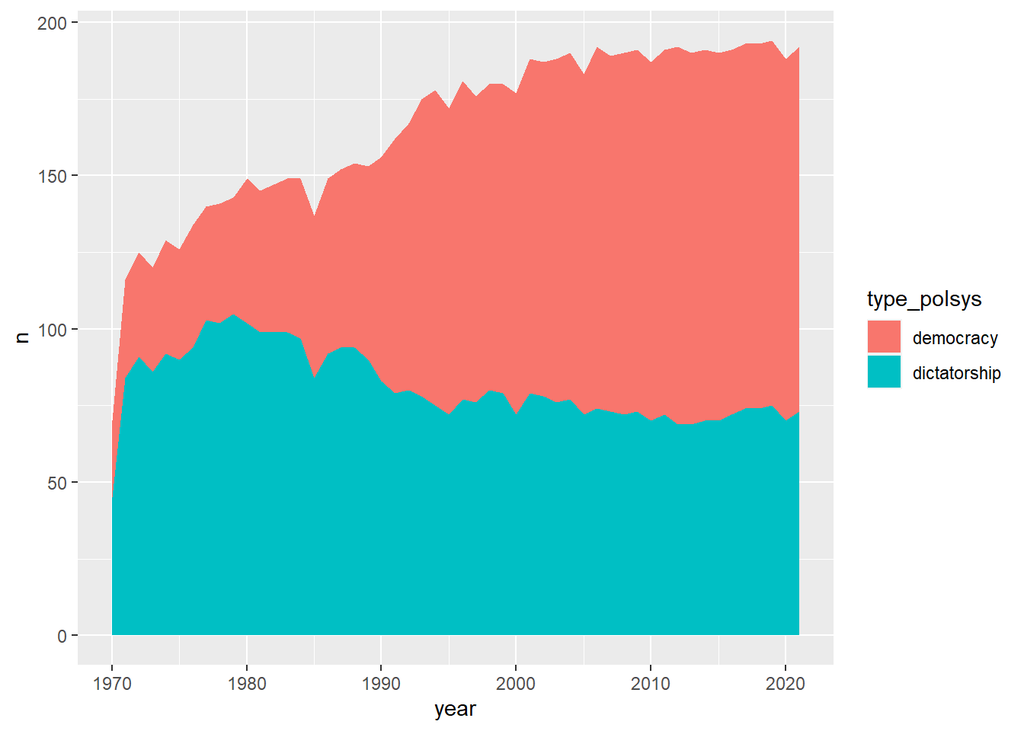

```r
ggplot (dem_dict, aes (x=year, y=n, fill= type_polsys)) +
  geom_area (stat= "identity", condition = "stack")
```

This is our basic graph. Let’s go back to the PowerPoint. So far, we have added three layers:

- *data*
- *aes*
- *geom*

Now that we have the basic plot done we can start working on the theme. For this plot, we will NOT use *facet* or *stats* layers.

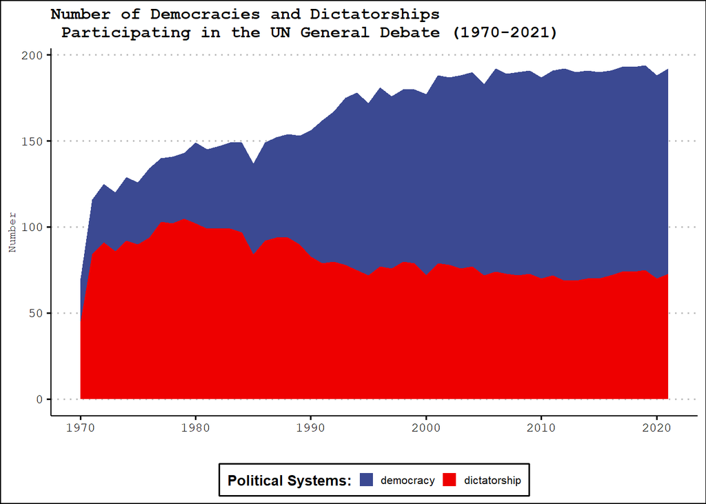

```r
ggplot (dem_dict, aes (x=year, y=n, fill= type_polsys)) +
  geom_area (stat= "identity", condition = "stack") +
  theme_clean () +
  scale_fill_aaas() +
  labs (fill= "Political Systems:")+
  theme (text = element_text(family= "mono"))+
  theme (legend.position = "bottom",
         legend.title = element_text (size=10, face ="bold"),
         legend.text = element_text(size = 8),
         legend.key.size = unit(.75,"line"))+
  theme (plot.title = element_text(size=12, face="bold"),
         axis.title = element_text (size=8))+
  labs (title= "Number of Democracies and Dictatorships\n Participating in the UN General Debate (1970-2021)",
        x = "",
        y = "Number")
```

## Treemap Plot

Using the UNGD metadata, we can try to figure out what governmental positions most of the female leaders hold when they address the UN General Debate. Note the code. We are interested only in women leaders. So we can filter the gender_lower to only women leaders. There are more than 20 positions listed in the dataframe. We will only look at the top 6 titles. Notice that we are looking at all the years in this plot.

```r
fem_post2 <- meta1 %>%
  filter (gender_lower == "female") %>%
  count (post) %>%
  arrange (desc (n)) %>%
  filter (post %in% c ("President", "Vice President", "Prime Minister", "Deputy Prime Minister", "Minister for Foreign Affairs", "UN Representative"))
```

Let’s feed the data to `ggplot`. Because we are plotting a treemap, we need to make sure that the `treemapify` package is already loaded - which I did so already. Note that the syntas used by the authors of this package is in line with `ggplot`’s grammar of graphics.

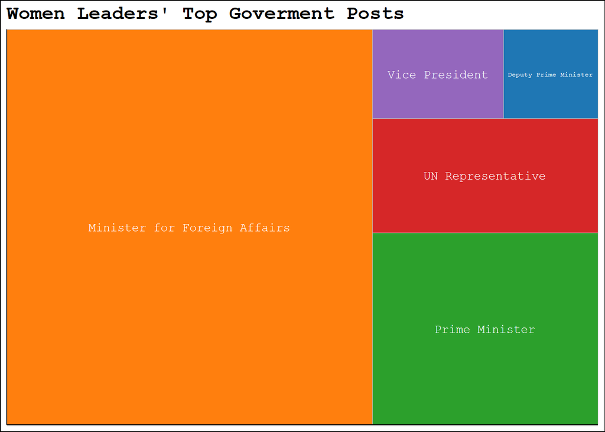

```r
ggplot(fem_post2,
       aes(fill = post,
           area = n,
           label = post)) +
  geom_treemap() +
  theme_clean ()+
  geom_treemap_text(color ="white", place = "centre", family = "mono", size =10)+
  theme(legend.position = "none")+
  labs(title = "Women Leaders' Top Goverment Posts")+
  theme (plot.title = element_text(size=16, face="bold", family="mono"))+
  scale_fill_d3()
```

## GEOM_COL Graph of Government Posts by Gender

Let’s wrangle and prepare the data from the UNGD metadata.

```r
gender_post <- meta1 %>%
  group_by (gender_lower) %>%
  count (post) %>%
  filter (gender_lower != "unknown") %>%
  filter (post %in% c ("President", "Vice President", "Prime Minister", "Deputy Prime Minister", "Minister for Foreign Affairs", "Deputy Minister for Foreign Affairs", "UN Representative"))
```

Let’s run our first graph.

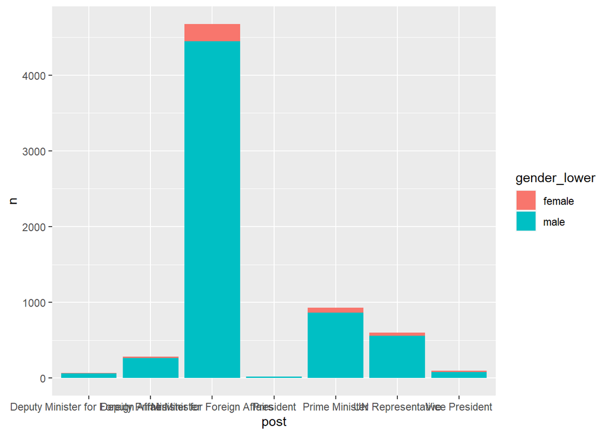

```r
ggplot (gender_post, aes(x=post, y=n, fill=gender_lower))+
  geom_col ()
```

I prefer to reorder from large to small and also flip the graph. We will use “coord_flip” function which is a *coordinate* layer!

In addition, note in the *aes* the code snippet after “x=”. I added the fct_reorder command to reorder the posts from highest to lowest. This is technically a *stat* layer but I did so in the *aes* layer.

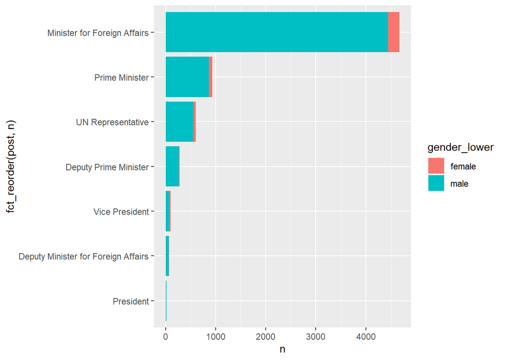

```r
ggplot (gender_post, aes (x=fct_reorder (post, n), y=n, fill =gender_lower)) +
  geom_col () +
  coord_flip()
```

Then we can add *theme* layers.

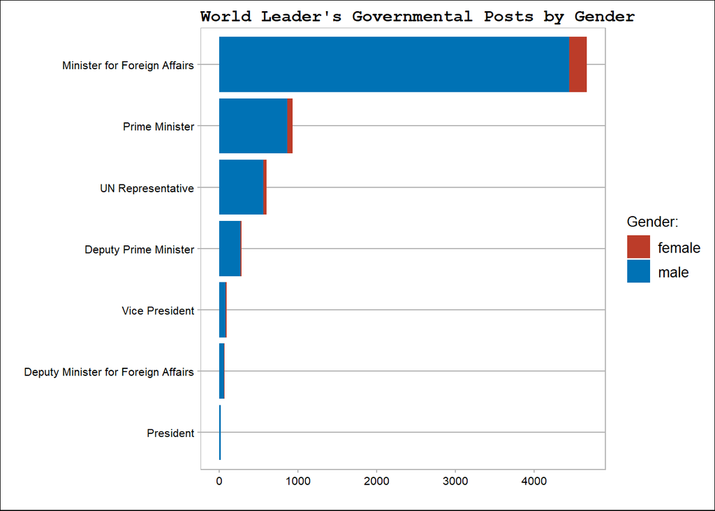

```r
ggplot (gender_post, aes (x=fct_reorder (post, n), y=n, fill =gender_lower)) +
  geom_col () +
  coord_flip()+
theme_calc ()+
  theme(legend.position = "right")+
  labs(title = "World Leader's Governmental Posts by Gender")+
  theme (plot.title = element_text(size=12, face="bold", family="mono", hjust= 0, vjust = 0))+
  labs (fill= "Gender:",
        x="",
        y="")+
  scale_fill_nejm()
```